# R Notebook

Is this relationship different between men and women? Choose an appropriate plot and interpret your findings.

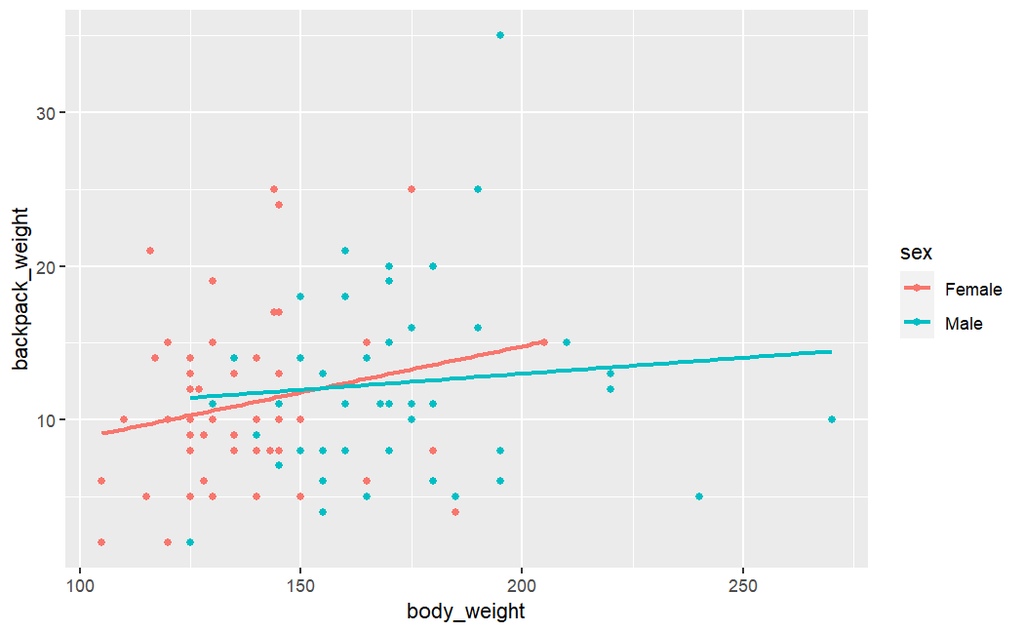

Females tended to have lower weight (below 150 lb) but were carrying backpacks weighing between 8-16kg/lb, while males weighed mainly over 150lb and were carrying backpacks with various weight.

What proportion of students report back pain?

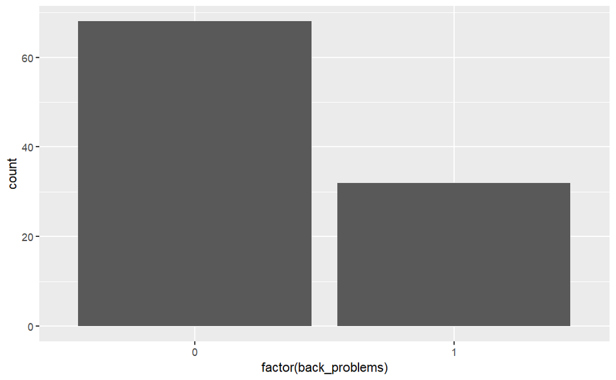

```r
ggplot(backpack)+
  aes(x = factor(back_problems))+
     geom_bar()
```

Around one third of students seemed to report back problems.

```r
ggplot(backpack)+
  aes(x = body_weight, fill = sex)+
  geom_bar()+
   geom_smooth(method = "lm", se = FALSE)
+
facet_wrap(~sex)
```

[output not shown]

Question 7.

Is this proportion different between men and women?

```r
ggplot(backpack)+
  aes(x = factor(back_problems), fill = sex)+
     geom_bar()
```

[output not shown]

Mostly females reported back problems.

Question 8.

Now you’ve investigated your data separately, create plots to describe the relationship between backpack weight, body weight, gender and reported backpain.

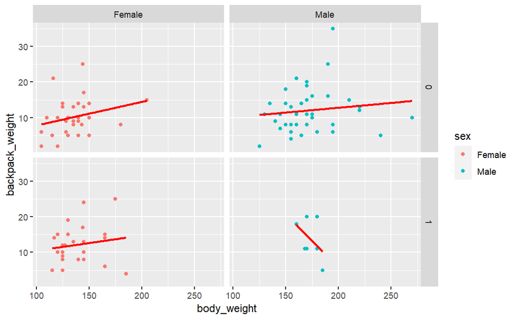

```r
ggplot(backpack)+
  aes( x = body_weight, y = backpack_weight, group = back_problems, col = sex )+
  geom_point()+
  geom_smooth(method = "lm",se = FALSE, color = "red")+
  facet_grid(~back_problems~sex)
```